# Innvotation & Research

## *LaLiga Data Analysis*

The first steps is charging the database and change the format of some variables to do the analysis

```python
#Libraries
import os
import subprocess
import pandas as pd
import numpy as np
import matplotlib.pyplot as plt
import seaborn as sns
import sqlite3
import warnings
warnings.filterwarnings('ignore')
sns.set_theme(style="whitegrid", context="talk", palette="muted")

# Read the data
with sqlite3.connect("laliga.sqlite") as con:
    data = pd.read_sql("SELECT * FROM Matches", con=con)

# Transformations in the data
df=data.copy()
df["home_goals"]=df["score"].str.split(":").str[0].astype(float)
df["away_goals"]=df["score"].str.split(":").str[1].astype(float)

df["results"]="NA"
df.loc[df["home_goals"]>df["away_goals"],"results"]="1"
df.loc[df["home_goals"]<df["away_goals"],"results"]="2"
df.loc[df["home_goals"]==df["away_goals"],"results"]="X"

NO_data=df.loc[df["results"]=="NA"]
df= df[df["results"] != "NA"]

df['datetime'] = pd.to_datetime(
        df['date'] + ' ' + df['time'],
        errors='coerce'
    )
df['weekday'] = df['datetime'].dt.day_name()
df['hour'] = df['datetime'].dt.hour + df['datetime'].dt.minute / 60
```

## Exercise 1

*Is it true that the home team is more likely to win? Make a pie chart showing the result distribution (whether home team wins, visitor team wins, or there’s a tie) of all matches in the data. Write in the plot the percentage of each category.*

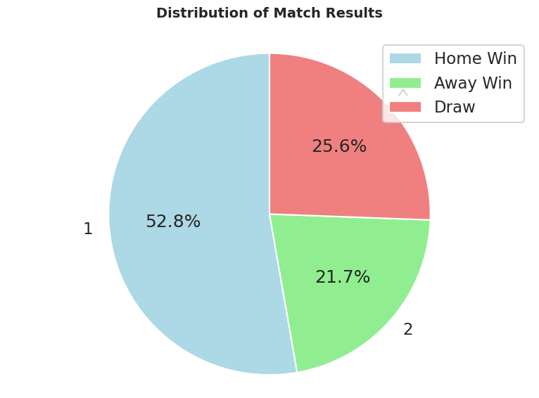

```python
fig, ax = plt.subplots(figsize=(8, 6))
order = ["1", "2", "X"]
colors = ["lightblue", "lightgreen", "lightcoral"]
labels = ["Home Win", "Away Win", "Draw"]

df["results"].value_counts().reindex(order).plot(
    kind="pie",
    autopct="%1.1f%%",
    startangle=90,
    colors=colors,
    ax=ax
)

ax.set_title("Distribution of Match Results", fontsize=14, fontweight="bold", pad=20)
ax.set_ylabel("")
ax.axis("equal")
plt.legend(["Home Win", "Away Win", "Draw"], loc="upper right")
plt.tight_layout()
plt.show()
```

**Conclusion**: In this case we can see that it is true. The home is more likely to win.

## Exercise 2

*What are the top ten scoring teams of all time? What are the ten teams that concede the most? Make two bar plot charts showing each of them. Consider only matches played in 1st division.*

```python
def calculate_team_stats(df, division=1):
    df_div = df[df['division'] == division]

    home_scored = (
        df_div.groupby('home_team')['home_goals']
        .sum()
        .reset_index()
        .rename(columns={'home_team': 'team', 'home_goals': 'goals'})
    )
    home_conceded = (
        df_div.groupby('home_team')['away_goals']
        .sum()
        .reset_index()
        .rename(columns={'home_team': 'team', 'away_goals': 'goals'})
    )


    away_scored = (
        df_div.groupby('away_team')['away_goals']
        .sum()
        .reset_index()
        .rename(columns={'away_team': 'team', 'away_goals': 'goals'})
    )
    away_conceded = (
        df_div.groupby('away_team')['home_goals']
        .sum()
        .reset_index()
        .rename(columns={'away_team': 'team', 'home_goals': 'goals'})
    )

    scored = (
        pd.concat([home_scored, away_scored])
        .groupby('team')['goals']
        .sum()
        .astype(int)
        .sort_values(ascending=False)
        .reset_index()
    )

    conceded = (
        pd.concat([home_conceded, away_conceded])
        .groupby('team')['goals']
        .sum()
        .astype(int)
        .sort_values(ascending=False)
        .reset_index()
    )

    return scored, conceded


goals_scored_df, goals_conceded_df = calculate_team_stats(df, division=1)
```

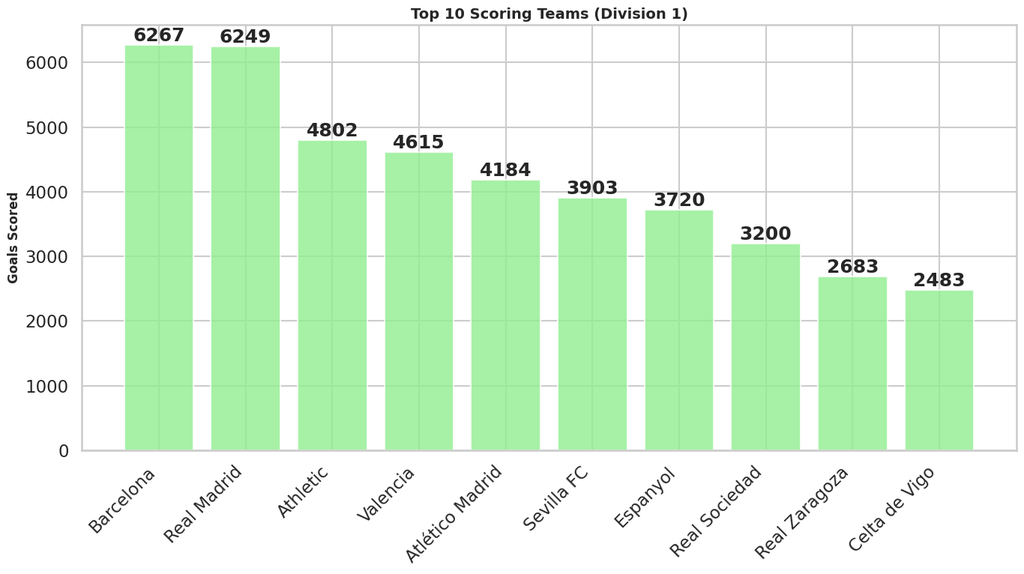

```python
def plot_top_scorers(scored_df, top_n=10, division=1):
    top_teams = scored_df.head(top_n)

    fig, ax = plt.subplots(figsize=(14, 8))
    bars = ax.bar(top_teams['team'], top_teams['goals'], color='lightgreen', alpha=0.8)

    # Add value labels
    for bar in bars:
        height = bar.get_height()
        ax.text(
            bar.get_x() + bar.get_width() / 2,
            height,
            f'{int(height)}',
            ha='center',
            va='bottom',
            fontweight='bold'
        )

    ax.set_ylabel('Goals Scored', fontsize=12, fontweight='bold')
    ax.set_title(f'Top 10 Scoring Teams (Division {division})', fontsize=14, fontweight='bold')
    ax.set_xticklabels(top_teams['team'], rotation=45, ha='right')
    plt.tight_layout()


plot_top_scorers(goals_scored_df, top_n=10, division=1)
```

**Conclusion**: On the one hand, the top 10 highest-scoring teams are shown in the plot. Barcelona and Real Madrid are by far the teams with the most goals scored. This may be due to the fact that both teams have consistently played in the 1st Division throughout the years covered by the dataset.

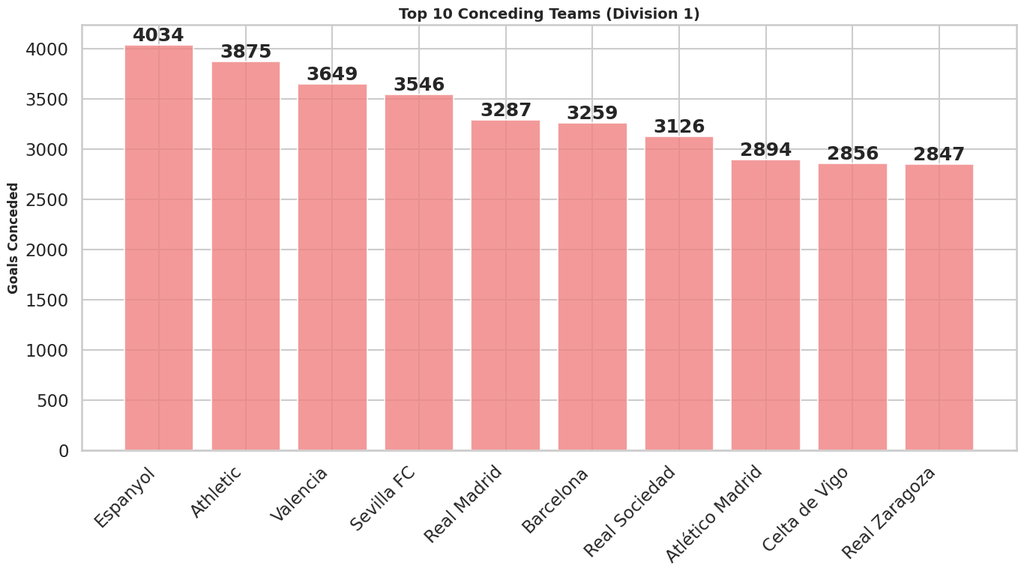

```python
def plot_top_conceded(conceded_df, top_n=10, division=1):
    top_teams = conceded_df.head(top_n)

    fig, ax = plt.subplots(figsize=(14, 8))
    bars = ax.bar(top_teams['team'], top_teams['goals'], color='lightcoral', alpha=0.8)

    # Add value labels
    for bar in bars:
        height = bar.get_height()
        ax.text(
            bar.get_x() + bar.get_width() / 2,
            height,
            f'{int(height)}',
            ha='center',
            va='bottom',
            fontweight='bold'
        )

    ax.set_ylabel('Goals Conceded', fontsize=12, fontweight='bold')
    ax.set_title(f'Top 10 Conceding Teams (Division {division})', fontsize=14, fontweight='bold')
    ax.set_xticklabels(top_teams['team'], rotation=45, ha='right')
    plt.tight_layout()


plot_top_conceded(goals_conceded_df, top_n=10, division=1)
```

**Conclusion**: On the other hand, the teams that conceded the most goals are more evenly matched, but Espanyol is the team that conceded the most goals.

What have been the biggest wins? Of course, when we say biggest we mean those with the highest goal difference. Show the top ten of them in a table.

```python
def get_biggest_wins(df, top_n=10):
    df_wins = df[df['home_goals'] != df['away_goals']].copy()
    df_wins['goal_diff'] = abs(df_wins['home_goals'] - df_wins['away_goals'])

    df_wins['winner'] = np.where(
        df_wins['home_goals'] > df_wins['away_goals'],
        df_wins['home_team'],
        df_wins['away_team']
    )

    df_wins['loser'] = np.where(
        df_wins['home_goals'] > df_wins['away_goals'],
        df_wins['away_team'],
        df_wins['home_team']
    )

    # Select top matches
    biggest = df_wins.nlargest(top_n, 'goal_diff')[
        ['date', 'season', 'division', 'winner', 'loser', 'score', 'goal_diff']
    ].reset_index(drop=True)

    biggest.index = range(1, len(biggest) + 1)
    biggest.index.name = 'Rank'

    return biggest
get_biggest_wins(df, top_n=10)
```

| Rank | date | season | division | winner | loser | score | goal_diff |
| --- | --- | --- | --- | --- | --- | --- | --- |
| 1 | 1/8/41 | 1940-1941 | 2 | Real Sociedad | Real Valladolid | 14:2 | 12.0 |
| 2 | 2/8/31 | 1930-1931 | 1 | Athletic | Barcelona | 12:1 | 11.0 |
| 3 | 1/13/57 | 1956-1957 | 2 | Real Gijón | Lérida | 11:0 | 11.0 |
| 4 | 9/29/40 | 1940-1941 | 1 | Sevilla FC | Barcelona | 11:1 | 10.0 |
| 5 | 9/28/41 | 1941-1942 | 1 | Sevilla FC | Real Oviedo | 10:0 | 10.0 |
| 6 | 1/11/42 | 1941-1942 | 1 | Athletic | Celta de Vigo | 10:0 | 10.0 |
| 7 | 11/19/50 | 1950-1951 | 1 | Athletic | Lérida | 10:0 | 10.0 |
| 8 | 9/4/49 | 1949-1950 | 2 | CE Sabadell | SD Erandio Club | 11:1 | 10.0 |
| 9 | 11/11/62 | 1962-1963 | 2 | Real Sociedad | CE Sabadell | 11:1 | 10.0 |
| 10 | 2/17/29 | 1928-1929 | 1 | Athletic | Espanyol | 9:0 | 9.0 |

**Conclusion**: The *biggest* wins in the 1st Division are surprisingly not by Barcelona or Real Madrid. Barcelona lost 2 matches in which they suffered heavy defeats.

## Exercise 3

*There has been a lot of discussion about how LaLiga’s television rights have changed game schedules in the last years. Make a bar plot chart showing the number of matches played each weekday, and make also a histogram of match time. Compare this two graphics between seasons 2000-2001 and 2020-2021*

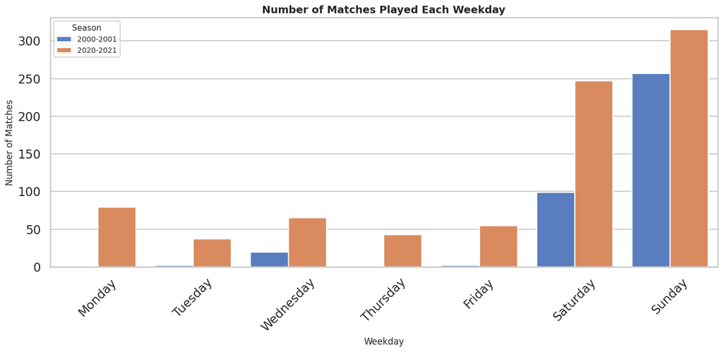

```python
def plot_weekday_distribution(seasons):
    df_filtered = df[df['season'].isin(seasons)]
    weekday_order = ['Monday', 'Tuesday', 'Wednesday', 'Thursday', 'Friday', 'Saturday', 'Sunday']

    fig, ax = plt.subplots(figsize=(14, 7))
    sns.countplot(
        data=df_filtered,
        x='weekday',
        hue='season',
        order=weekday_order,
        ax=ax
    )

    ax.set_title('Number of Matches Played Each Weekday', fontsize=14, fontweight='bold')
    ax.set_xlabel('Weekday', fontsize=12)
    ax.set_ylabel('Number of Matches', fontsize=12)
    ax.legend(title='Season', title_fontsize=11, fontsize=10)
    plt.xticks(rotation=45)
    plt.tight_layout()
    plt.show()

plot_weekday_distribution(seasons=['2000-2001', '2020-2021'])
```

**Conclusion**: We can see that in the 2020–2021 season, most matches were played on weekends. This is likely because people prefer to watch football on weekends.

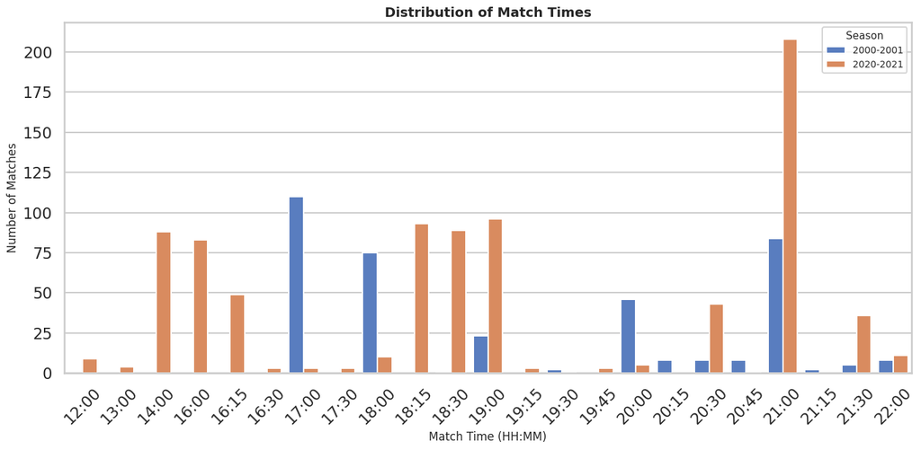

```python
def plot_match_time(seasons):
    df_filtered = df[df['season'].isin(seasons)]
    def to_time_str(x):
        if pd.isna(x):
            return np.nan
        h = int(x)
        m = int(round((x - h) * 60))
        if m == 60:
            h = (h + 1) % 24
            m = 0
        return f"{h:02d}:{m:02d}"
    df_filtered['hour_label'] = df_filtered['hour'].apply(to_time_str)


    order = sorted(df_filtered['hour_label'].dropna().unique(),
                   key=lambda t: int(t.split(':')[0]) + int(t.split(':')[1])/60)

    fig, ax = plt.subplots(figsize=(14, 7))
    sns.countplot(
        data=df_filtered,
        x='hour_label',
        hue='season',
        ax=ax,
        order=order
    )
    ax.set_title('Distribution of Match Times', fontsize=14, fontweight='bold')
    ax.set_xlabel('Match Time (HH:MM)', fontsize=12)
    ax.set_ylabel('Number of Matches', fontsize=12)
    ax.legend(title='Season', title_fontsize=11, fontsize=10)
    plt.xticks(rotation=45)
    plt.tight_layout()
    plt.show()

plot_match_time(seasons=['2000-2001', '2020-2021'])
```

## Exercise 4

*Build a cross results table for season 2020-2021 (1st division). Figure 1 is an example taken from Wikipedia. Try to make it the most similar to this one: use team abbreviations as column names and paint the background of each cell according to result (green in case local team wins and red in case visitor team wins). Also, could you model the intensity of this background color with the goal difference from the match?*

*Write a function that, given the season and division, plots the cross results table. Function prototype should be like plot_cross_results_table(season, division) and return the plot object*

```python
def plot_cross_results_table(season, division):

    df_filtered = df[(df['season'] == season) & (df['division'] == division)].copy()
    if df_filtered.empty:
        print(f"No data for season {season}-{season+1}, division {division}")
        return None

    abbr = {
        "MADRID": "RMA", "SOCIEDAD": "RSO", "VALLADOLID": "RVA"
    }

    def make_abbr(team):
        team_up = team.upper()
        if team_up.startswith("REAL "):
            team_up = team_up[5:]
        if team_up.startswith("SD ") or team_up.startswith("CA ") or team_up.startswith("FC "):
            team_up = team_up[3:]
        return abbr.get(team_up, team_up[:3])

    df_filtered["Home"] = df_filtered["home_team"].apply(make_abbr)
    df_filtered["Away"] = df_filtered["away_team"].apply(make_abbr)

    self_matches = df_filtered[df_filtered['Home'] == df_filtered['Away']]
    if not self_matches.empty:
        print("⚠️ WARNING: Found matches where teams play against themselves:")
        print(self_matches[['date', 'home_team', 'away_team', 'home_abbr', 'away_abbr']])
        df_filtered = df_filtered[df_filtered['Home'] != df_filtered['Away']]

    df_filtered["score_str"] = (
        df_filtered["home_goals"].astype(int).astype(str) + ":" + df_filtered["away_goals"].astype(int).astype(str)
    )
    df_filtered["goal_diff"] = df_filtered["home_goals"] - df_filtered["away_goals"]

    tabla = pd.crosstab(
        df_filtered["Home"],
        df_filtered["Away"],
        values=df_filtered.apply(lambda x: (x["score_str"], x["goal_diff"]), axis=1),
        aggfunc="first"
    )

    tabla_score = tabla.map(lambda x: x[0] if pd.notna(x) else "-")
    tabla_diff = tabla.map(lambda x: x[1] if pd.notna(x) else 0)
    abbr_to_full = df_filtered.drop_duplicates(subset=["Home"])[["Home", "home_team"]]
    abbr_to_full = dict(zip(abbr_to_full["Home"], abbr_to_full["home_team"]))

    tabla_score.index = tabla_score.index.map(abbr_to_full)
    tabla_diff.index = tabla_diff.index.map(abbr_to_full)

    def color_cell(val, diff):
        if val == "-":
            return "background-color: #lightgray; text-align:center; color:#ccc"

        if diff == 0:
            return "background-color: #FFF59D; color: black; text-align:center; font-weight:bold"

        max_diff = 5
        intensity = 0.5 + 0.5 * (1 - min(abs(diff) / max_diff, 1))

        if diff > 0:
            color = f"rgba(60, 220, 60, {intensity})"
        else:
            color = f"rgba(255, 50, 50, {intensity})"

        return f"background-color: {color}; color:black; text-align:center; font-weight:bold"


    def style_table(df_score, df_diff):
        def style_row(row):
            return [
                color_cell(row[col], df_diff.loc[row.name, col])
                for col in df_score.columns
            ]
        return df_score.style.apply(style_row, axis=1)

    tabla_styled = style_table(tabla_score, tabla_diff)
    tabla_styled.set_caption(f"LaLiga Division {division} ({season}): Cross Results (Home vs Away)")

    return tabla_styled




table = plot_cross_results_table("2020-2021", 1)
table
```

LaLiga Division 1 (2020-2021): Cross Results (Home vs Away)

| Away Home | ALA | ATH | ATL | BAR | BET | CEL | CÁD | EIB | ELC | GET | GRA | HUE | LEV | OSA | RMA | RSO | RVA | SEV | VAL | VIL |
| --- | --- | --- | --- | --- | --- | --- | --- | --- | --- | --- | --- | --- | --- | --- | --- | --- | --- | --- | --- | --- |
| Alavés | - | 1:0 | 1:2 | 1:1 | 0:1 | 1:3 | 1:1 | 2:1 | 0:2 | 0:0 | 4:2 | 1:0 | 2:2 | 0:1 | 1:4 | 0:0 | 1:0 | 1:2 | 2:2 | 2:1 |
| Athletic | 0:0 | - | 2:1 | 2:3 | 4:0 | 0:2 | 0:1 | 1:1 | 1:0 | 5:1 | 2:1 | 2:0 | 2:0 | 2:2 | 0:1 | 0:1 | 2:2 | 2:1 | 1:1 | 1:1 |
| Atlético Madrid | 1:0 | 2:1 | - | 1:0 | 2:0 | 2:2 | 4:0 | 5:0 | 3:1 | 1:0 | 6:1 | 2:0 | 0:2 | 2:1 | 1:1 | 2:1 | 2:0 | 2:0 | 3:1 | 0:0 |
| Barcelona | 5:1 | 2:1 | 0:0 | - | 5:2 | 1:2 | 1:1 | 1:1 | 3:0 | 5:2 | 1:2 | 4:1 | 1:0 | 4:0 | 1:3 | 2:1 | 1:0 | 1:1 | 2:2 | 4:0 |
| Real Betis | 3:2 | 0:0 | 1:1 | 2:3 | - | 2:1 | 1:0 | 0:2 | 3:1 | 1:0 | 2:1 | 1:0 | 2:0 | 1:0 | 2:3 | 0:3 | 2:0 | 1:1 | 2:2 | 1:1 |
| Celta de Vigo | 2:0 | 0:0 | 0:2 | 0:3 | 2:3 | - | 4:0 | 1:1 | 3:1 | 1:0 | 3:1 | 2:1 | 2:0 | 2:1 | 1:3 | 1:4 | 1:1 | 3:4 | 2:1 | 0:4 |
| Cádiz CF | 3:1 | 0:4 | 2:4 | 2:1 | 0:1 | 0:0 | - | 1:0 | 1:3 | 0:2 | 1:1 | 2:1 | 2:2 | 0:2 | 0:3 | 0:1 | 0:0 | 1:3 | 2:1 | 0:0 |
| SD Eibar | 3:0 | 1:2 | 1:2 | 0:1 | 1:1 | 0:0 | 0:2 | - | 0:1 | 0:0 | 2:0 | 1:1 | 0:1 | 0:0 | 1:3 | 0:1 | 1:1 | 0:2 | 0:0 | 1:3 |
| Elche CF | 0:2 | 2:0 | 0:1 | 0:2 | 1:1 | 1:1 | 1:1 | 1:0 | - | 1:3 | 0:1 | 0:0 | 1:0 | 2:2 | 1:1 | 0:3 | 1:1 | 2:1 | 2:1 | 2:2 |
| Getafe | 0:0 | 1:1 | 0:0 | 1:0 | 3:0 | 1:1 | 0:1 | 0:1 | 1:1 | - | 0:1 | 1:0 | 2:1 | 1:0 | 0:0 | 0:1 | 0:1 | 0:1 | 3:0 | 1:3 |
| Granada CF | 2:1 | 2:0 | 1:2 | 0:4 | 2:0 | 0:0 | 0:1 | 4:1 | 2:1 | 0:0 | - | 3:3 | 1:1 | 2:0 | 1:4 | 1:0 | 1:3 | 1:0 | 2:1 | 0:3 |
| SD Huesca | 1:0 | 1:0 | 0:0 | 0:1 | 0:2 | 3:4 | 0:2 | 1:1 | 3:1 | 0:2 | 3:2 | - | 1:1 | 0:0 | 1:2 | 1:0 | 2:2 | 0:1 | 0:0 | 0:0 |
| Levante | 1:1 | 1:1 | 1:1 | 3:3 | 4:3 | 1:1 | 2:2 | 2:1 | 1:1 | 3:0 | 2:2 | 0:2 | - | 0:1 | 0:2 | 2:1 | 2:2 | 0:1 | 1:0 | 1:5 |
| CA Osasuna | 1:1 | 1:0 | 1:3 | 0:2 | 0:2 | 2:0 | 3:2 | 2:1 | 2:0 | 0:0 | 3:1 | 1:1 | 1:3 | - | 0:0 | 0:1 | 0:0 | 0:2 | 3:1 | 1:3 |
| Real Madrid | 1:2 | 3:1 | 2:0 | 2:1 | 0:0 | 2:0 | 0:1 | 2:0 | 2:1 | 2:0 | 2:0 | 4:1 | 1:2 | 2:0 | - | 1:1 | 1:0 | 2:2 | 2:0 | 2:1 |
| Real Sociedad | 4:0 | 1:1 | 0:2 | 1:6 | 2:2 | 2:1 | 4:1 | 1:1 | 2:0 | 3:0 | 2:0 | 4:1 | 1:0 | 1:1 | 0:0 | - | 4:1 | 1:2 | 0:1 | 1:1 |
| Real Valladolid | 0:2 | 2:1 | 1:2 | 0:3 | 1:1 | 1:1 | 1:1 | 1:2 | 2:2 | 2:1 | 1:2 | 1:3 | 1:1 | 3:2 | 0:1 | 1:1 | - | 1:1 | 0:1 | 0:2 |
| Sevilla FC | 1:0 | 0:1 | 1:0 | 0:2 | 1:0 | 4:2 | 3:0 | 0:1 | 2:0 | 3:0 | 2:1 | 1:0 | 1:0 | 1:0 | 0:1 | 3:2 | 1:1 | - | 1:0 | 2:0 |
| Valencia | 1:1 | 2:2 | 0:1 | 2:3 | 0:2 | 2:0 | 1:1 | 4:1 | 1:0 | 2:2 | 2:1 | 1:1 | 4:2 | 1:1 | 4:1 | 2:2 | 3:0 | 0:1 | - | 2:1 |
| Villarreal | 3:1 | 1:1 | 0:2 | 1:2 | 1:2 | 2:4 | 2:1 | 2:1 | 0:0 | 1:0 | 2:2 | 1:1 | 2:1 | 1:2 | 1:1 | 1:1 | 2:0 | 4:0 | 2:1 | - |

## Exercise 5

*As you surely know, there has always been a historical rivalry between Barcelona and Real Madrid. But which of them has won the most games in direct confrontations? Which of them has scored the most goals in these games? Show both things in two pie charts, side by side. Remember to consider ties in the first one. Write a function that, given two team names,plots the two graphs described above. Function prototype should be like plot_direct_confrontations_stats(team1, team2) and return the plot object. Use it with some other classical*rivals like Betis and Sevilla.

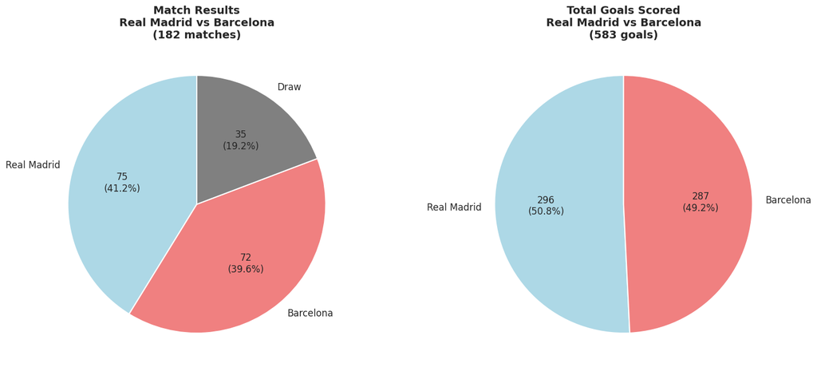

```python
def plot_direct_confrontations_stats(team1, team2, df=df):

    aux = df[
        ((df["away_team"] == team2) & (df["home_team"] == team1)) |
        ((df["away_team"] == team1) & (df["home_team"] == team2))
    ].copy()

    if aux.empty:
        print(f"No matches found between {team1} and {team2}")
        return None


    team1_home = aux['home_team'] == team1
    team1_goals = (aux.loc[team1_home, 'home_goals'].sum() + aux.loc[team1_home, 'away_goals'].sum())
    team2_goals = (aux.loc[~team1_home, 'away_goals'].sum() + aux.loc[~team1_home, 'home_goals'].sum())


    aux['goal_diff'] = aux['home_goals'] - aux['away_goals']
    aux.loc[~team1_home, 'goal_diff'] *= -1  # Invert for matches where team1 is away


    aux['winner'] = 'Draw'
    aux.loc[aux['goal_diff'] > 0, 'winner'] = team1
    aux.loc[aux['goal_diff'] < 0, 'winner'] = team2

    results_count = aux['winner'].value_counts()


    color_map = {team1: 'lightblue', 'Draw': 'grey', team2: 'lightcoral'}
    results_labels = results_count.index.tolist()
    results_values = results_count.values.tolist()
    results_colors = [color_map[label] for label in results_labels]

    goals_labels = [team1, team2]
    goals_values = [team1_goals, team2_goals]
    goals_colors = ['lightblue', 'lightcoral']


    fig, (ax1, ax2) = plt.subplots(1, 2, figsize=(16, 7))

    # Pie chart 1: Match results
    total_matches = sum(results_values)
    ax1.pie(results_values, labels=results_labels,
            autopct=lambda pct, total=total_matches: f'{int(round(pct*total/100))}\n({pct:.1f}%)',
            startangle=90, colors=results_colors, textprops={'fontsize': 12})
    ax1.set_title(f'Match Results\n{team1} vs {team2}\n({total_matches} matches)',
                  fontsize=14, fontweight='bold')

    # Pie chart 2: Goals scored
    total_goals = sum(goals_values).astype(int)
    ax2.pie(goals_values, labels=goals_labels,
            autopct=lambda pct, total=total_goals: f'{int(round(pct*total/100))}\n({pct:.1f}%)',
            startangle=90, colors=goals_colors, textprops={'fontsize': 12})
    ax2.set_title(f'Total Goals Scored\n{team1} vs {team2}\n({total_goals} goals)',
                  fontsize=14, fontweight='bold')

    plt.tight_layout()
    return fig

fig= plot_direct_confrontations_stats("Real Madrid", "Barcelona")
plt.show()
```

**Conclusion**: We can see that Real Madrid has won more games against Barcelona and has scored more goals.

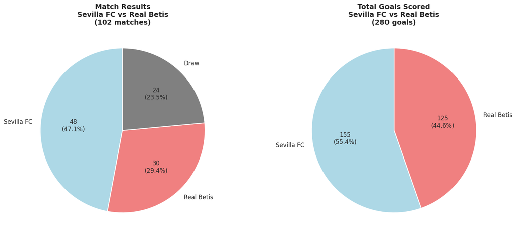

```python
fig= plot_direct_confrontations_stats("Sevilla FC", "Real Betis")
plt.show()
```

**Conclusion**: In this case, Sevilla FC has won more games against Real Betis and scored more goals. The difference is even greater when compared to Barcelona and Real Madrid.

## Exercise 6

*Between 1979 and 1980, Real Sociedad managed to chain a total of 38 games without losing. That was, by far, the longest undefeated streak in their history. Which teams have had the longest undefeated streaks? Show the longest undefeated streaks in a horizontal bar plot, indicating in each bar the team name and the dates it held that streak, for instance, Real Sociedad 22/04/1979- 04/05/1980.*

```
================================================================================
TOP 10 LONGEST UNDEFEATED STREAKS IN LA LIGA
================================================================================
Barcelona                       43 games  (15/04/2017 - 09/05/2018)
Real Sociedad                   38 games  (29/04/1979 - 04/05/1980)
Real Madrid                     31 games  (08/05/1988 - 09/04/1989)
Real Valladolid                 29 games  (07/10/2006 - 29/04/2007)
Atlético Madrid                 26 games  (08/02/2020 - 05/12/2020)
Sporting Gijón                  25 games  (10/05/2014 - 11/01/2015)
Espanyol                        22 games  (17/10/1993 - 13/03/1994)
Dep. La Coruña                  22 games  (06/03/1994 - 06/11/1994)
UD Las Palmas                   21 games  (04/10/1997 - 07/02/1998)
Valencia                        21 games  (11/01/1942 - 22/11/1942)
================================================================================
```

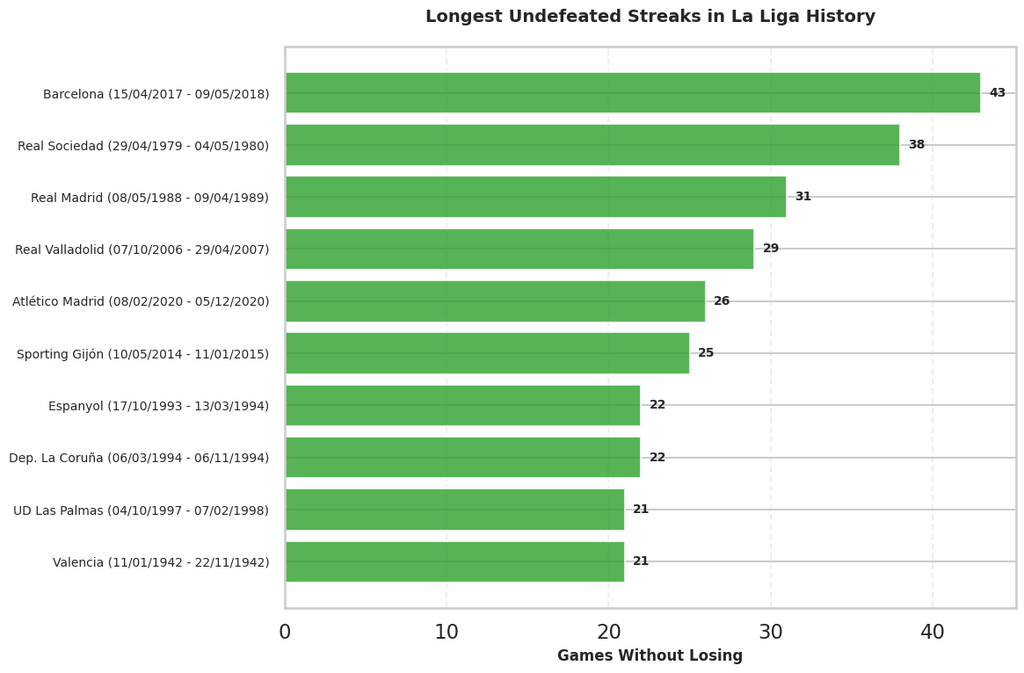

```python
def find_longest_undefeated_streaks(top_n=15,df=df):

    df = df.copy()

    df[['month','day','year2']] = df['date'].str.split('/', expand=True).astype(int)
    df['year'] = df['year2'].apply(lambda y: 2000+y if y <= 21 else 1900+y)

    df['date_fixed'] = pd.to_datetime(df[['year','month','day']])

    home = df[['date_fixed','home_team','home_goals','away_goals']].copy()
    home.columns = ['date','team','goals_for','goals_against']

    away = df[['date_fixed','away_team','away_goals','home_goals']].copy()
    away.columns = ['date','team','goals_for','goals_against']

    matches = pd.concat([home, away]).sort_values(['team','date']).reset_index(drop=True)

    matches['defeat'] = matches['goals_for'] < matches['goals_against']
    matches['streak_group'] = matches.groupby('team')['defeat'].cumsum()

    undefeated = matches[~matches['defeat']].copy()

    streaks = undefeated.groupby(['team','streak_group']).agg({
        'date': ['min','max','count']
    }).reset_index()

    streaks.columns = ['team','streak_group','start_date','end_date','streak']

    longest = streaks.loc[streaks.groupby('team')['streak'].idxmax()].copy()
    longest = longest.sort_values('streak', ascending=False).head(top_n).reset_index(drop=True)

    longest['label'] = longest.apply(
        lambda x: f"{x['team']} ({x['start_date'].strftime('%d/%m/%Y')} - {x['end_date'].strftime('%d/%m/%Y')})",
        axis=1
    )

    fig, ax = plt.subplots(figsize=(12,8))
    bars = ax.barh(range(len(longest)), longest['streak'], color='#2ca02c', alpha=0.8)

    for i, (bar, streak) in enumerate(zip(bars, longest['streak'])):
        ax.text(bar.get_width()+0.5, bar.get_y()+bar.get_height()/2, f'{int(streak)}', va='center', fontsize=10, fontweight='bold')

    ax.set_yticks(range(len(longest)))
    ax.set_yticklabels(longest['label'], fontsize=10)
    ax.set_xlabel('Games Without Losing', fontsize=12, fontweight='bold')
    ax.set_title('Longest Undefeated Streaks in La Liga History', fontsize=14, fontweight='bold', pad=20)
    ax.grid(axis='x', alpha=0.3, linestyle='--')
    ax.set_axisbelow(True)
    ax.invert_yaxis()

    plt.tight_layout()

    print(f"\n{'='*80}")
    print(f"TOP {top_n} LONGEST UNDEFEATED STREAKS IN LA LIGA")
    print(f"{'='*80}")
    for _, row in longest.iterrows():
        print(f"{row['team']:30} {int(row['streak']):3} games  "
              f"({row['start_date'].strftime('%d/%m/%Y')} - {row['end_date'].strftime('%d/%m/%Y')})")
    print(f"{'='*80}\n")

    return fig

fig = find_longest_undefeated_streaks(top_n=10)
plt.show()
```

## Exercise 7

*Create a table with the final standings of each season (and division), that is, a table that contains all the teams ordered (in descending order) by the number of points they got during that season, and some other aggregate statistics. The table must contain the following columns: season, division, ranking, team, GF (total goals scored), GA (total goals conceded), GD (goals difference), W (total wins), L (total loses), T (total ties), Pts (points). Remember that, in football, you earn 3 points per victory, and 1 point per tie (none for loses). In case two teams have same number of points, order by GD (descending), and then by GF (also descending). Order the table so that standings of one season come before standings of previous one, and standings of 1st division come before standings of 2nd division.*

**Save the final table in Excel with the name SeasonStandings.xlsx in the reports/ folder.**

```python
def final_standings(df=df):

    df_filtered = df.loc[df["season"]!="2021-2022"].copy()
    home = df_filtered[['season', 'division', 'home_team', 'home_goals', 'away_goals']].copy()
    home = home.rename(columns={
    'home_team': 'team',
    'home_goals': 'GF',
    'away_goals': 'GA'
    })
    home['W'] = (home['GF'] > home['GA']).astype(int)
    home['L'] = (home['GF'] < home['GA']).astype(int)
    home['T'] = (home['GF'] == home['GA']).astype(int)

    away = df_filtered[['season', 'division', 'away_team', 'home_goals', 'away_goals']].copy()
    away = away.rename(columns={
    'away_team': 'team',
    'away_goals': 'GF',
    'home_goals': 'GA'
    })
    away['W'] = (away['GF'] > away['GA']).astype(int)
    away['L'] = (away['GF'] < away['GA']).astype(int)
    away['T'] = (away['GF'] == away['GA']).astype(int)

    # Unimos ambos
    matches = pd.concat([home, away], ignore_index=True)
    standings = (
    matches.groupby(['season', 'division', 'team'], as_index=False)
            .agg({
                'GF': 'sum',
                'GA': 'sum',
                'W': 'sum',
                'L': 'sum',
                'T': 'sum'
            })
    )
    standings['GF'] = (standings['GF']).astype(int)
    standings['GA'] = (standings['GA']).astype(int)
    standings['GD'] = (standings['GF'] - standings['GA']).astype(int)
    standings['Pts'] = (standings['W'] * 3 + standings['T']).astype(int)

    standings = standings.sort_values(
    by=['season', 'division', 'Pts', 'GD', 'GF'],
    ascending=[False, True, False, False, False]
    )
    standings['ranking'] = standings.groupby(['season', 'division']).cumcount() + 1
    standings = standings[['season', 'division', 'ranking', 'team', 'GF', 'GA', 'GD', 'W', 'L', 'T', 'Pts']]
    return standings.reset_index(drop=True)

standings = final_standings()
standings
```

|  | season | division | ranking | team | GF | GA | GD | W | L | T | Pts |
| --- | --- | --- | --- | --- | --- | --- | --- | --- | --- | --- | --- |
| 0 | 2020-2021 | 1 | 1 | Atlético Madrid | 67 | 25 | 42 | 26 | 4 | 8 | 86 |
| 1 | 2020-2021 | 1 | 2 | Real Madrid | 67 | 28 | 39 | 25 | 4 | 9 | 84 |
| 2 | 2020-2021 | 1 | 3 | Barcelona | 85 | 38 | 47 | 24 | 7 | 7 | 79 |
| 3 | 2020-2021 | 1 | 4 | Sevilla FC | 53 | 33 | 20 | 24 | 9 | 5 | 77 |
| 4 | 2020-2021 | 1 | 5 | Real Sociedad | 59 | 38 | 21 | 17 | 10 | 11 | 62 |
| ... | ... | ... | ... | ... | ... | ... | ... | ... | ... | ... | ... |
| 2739 | 1928-1929 | 1 | 6 | Athletic Madrid | 43 | 41 | 2 | 8 | 8 | 2 | 26 |
| 2740 | 1928-1929 | 1 | 7 | Espanyol | 32 | 38 | -6 | 7 | 7 | 4 | 25 |
| 2741 | 1928-1929 | 1 | 8 | Catalunya | 45 | 49 | -4 | 6 | 8 | 4 | 22 |
| 2742 | 1928-1929 | 1 | 9 | Real Unión | 40 | 42 | -2 | 5 | 11 | 2 | 17 |
| 2743 | 1928-1929 | 1 | 10 | Racing | 25 | 50 | -25 | 3 | 12 | 3 | 12 |

2744 rows × 11 columns

```python
os.makedirs('reports', exist_ok=True)
standings.to_excel('reports/SeasonStandings.xlsx', index=False)
```

## Exercise 8

*Villarreal is a team that has grown a lot in recent decades. Specially ever since some billionaire guy bought it (Fernando Roig, from Mercadona).Make a line plot showing the rank of Villarreal at the end of each season, from the oldest ones (left) to the earliest ones (right). Consider rankings in 2nd division to be a continuation of the 1st one, that is, if there’s N teams in 1st division and Villarreal got **r** position in 2nd division, then it should be placed in **N +r**. Draw in the same plot a line showing the cut between 1st and 2nd division.*

*Write a function that, given *n* team names, plots the graph described above of each one of them superposed. Function prototype should be like **plot_ranking_evolution(team1, team2, ..., teamN)** and return the plot object (note that function should not take one array-type argument, but **n** arguments). Use it to compare the evolution of all the teams that currently play in 1st division.*

```python
def plot_ranking_evolution(*teams):
    df = standings[['season', 'division', 'ranking', 'team']].copy()

    df['season_start'] = df['season'].str.extract(r'(\d{4})')[0].astype(int)
    df = df.sort_values(by='season_start')

    first_div_counts = (
        df[df['division'] == 1]
        .groupby('season_start')['team']
        .count()
        .rename('first_div_teams')
    )

    df = df.merge(first_div_counts, on='season_start', how='left')

    df['adj_ranking'] = np.where(
        df['division'] != 1,
        df['ranking'] + df['first_div_teams'],
        df['ranking']
    )

    plt.figure(figsize=(25, 10))

    for team in teams:
        team_df = df[df['team'] == team].copy()
        if team_df.empty:
            print(f"⚠️ The team '{team}' is not found in the data.")
            continue

        team_df = team_df.sort_values('season_start')
        plt.plot(
            team_df['season_start'], team_df['adj_ranking'],
            marker='o', label=team
        )

    avg_cut = df.groupby('season_start')['first_div_teams'].mean().sort_index()
    plt.plot(
        avg_cut.index, avg_cut.values,
        color='red', linestyle='--', label='Cut between 1st and 2nd division'
    )

    plt.gca().invert_yaxis()
    plt.title("Ranking Evolution by Season")
    plt.xlabel("Season")
    plt.ylabel("Final Position (lower = better)")
    plt.legend()
    plt.grid(True, linestyle=':', alpha=0.6)

    season_labels = (
        df[['season_start', 'season']]
        .drop_duplicates()
        .sort_values('season_start')
    )
    plt.xticks(
        season_labels['season_start'],
        season_labels['season'],
        rotation=90
    )

    plt.tight_layout()
    return plt
```

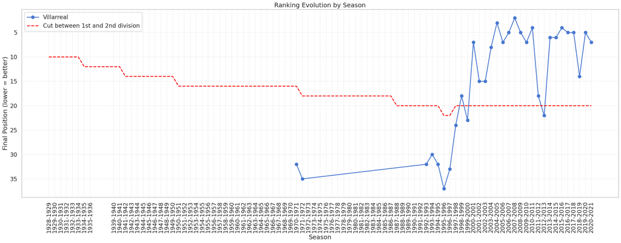

```python
plot_ranking_evolution('Villarreal').show()
```

```python
standings['season_start'] = standings['season'].str.extract(r'(\d{4})')[0].astype(int)
latest_season = standings['season_start'].max()
teams_first_div = (
    standings[
        (standings['season_start'] == latest_season) &
        (standings['division'] == 1)
    ]['team']
    .unique()
)
print(f"Teams in First Division in Season {latest_season}:")
print(teams_first_div)
```

```
Teams in First Division in Season 2020:
['Atlético Madrid' 'Real Madrid' 'Barcelona' 'Sevilla FC' 'Real Sociedad'
 'Real Betis' 'Villarreal' 'Celta de Vigo' 'Athletic' 'Granada CF'
 'CA Osasuna' 'Cádiz CF' 'Valencia' 'Levante' 'Getafe' 'Alavés' 'Elche CF'
 'SD Huesca' 'Real Valladolid' 'SD Eibar']
```

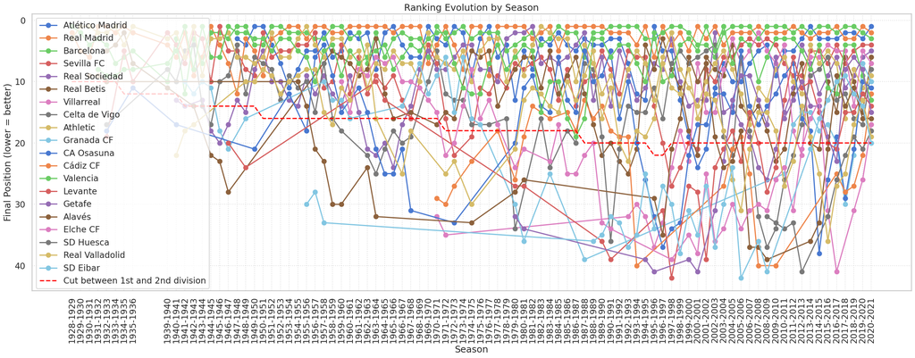

```python
plot_ranking_evolution(*teams_first_div).show()
```

**Conclusion**: First of all, we can see that from the season 1936-1937 to the season 1938-1939 we dont have any data, due to the Spanish Civil War. Another thing that we can see is the fact that in all seasons we dont have the same teams in the competitions, we start the competition in 1928 with 10 teams and nowadays we have 20 teams in the competition. An interesting observation is that Barcelona, Real Madrid and Atéltico Madrid in the last years, since season 2012-2013, always stay in the top 3 teams in the first Divsion.

## Exercise 9

*In football jargon, those teams that are permanently descending and ascending between 1st and 2nd division are called **elevator teams**. What are the most elevator teams in LaLiga? Plot the history of the top 5 of them using the function from exercise 9*

```python
def calculate_promotions_relegations(df=standings):
    df_1st = df[df['division'] == 1].copy()

    if 'season_start' not in df_1st.columns:
        df_1st['season_start'] = df_1st['season'].str.extract(r'(\d{4})')[0].astype(int)

    df_1st = df_1st.sort_values('season_start')

    seasons = sorted(df_1st['season_start'].unique())

    stats = {team: {'ascensos': 0, 'descensos': 0} for team in df_1st['team'].unique()}

    for i in range(1, len(seasons)):
        prev_teams = set(df_1st[df_1st['season_start'] == seasons[i-1]]['team'])
        curr_teams = set(df_1st[df_1st['season_start'] == seasons[i]]['team'])


        for t in curr_teams - prev_teams:
            stats[t]['ascensos'] += 1

        for t in prev_teams - curr_teams:
            stats[t]['descensos'] += 1

    elevator_stats = pd.DataFrame(stats).T # Transpose to have teams as rows
    elevator_stats['team'] = elevator_stats.index
    elevator_stats = elevator_stats.reset_index(drop=True)  # eliminar índice original
    elevator_stats['total'] = elevator_stats['ascensos'] + elevator_stats['descensos']
    elevator_stats = elevator_stats.sort_values('total', ascending=False)
    elevator_stats = elevator_stats[['team', 'ascensos', 'descensos', 'total']]
    elevator_stats = elevator_stats.reset_index(drop=True)

    return elevator_stats

elevator_stats = calculate_promotions_relegations(standings)
elevator_stats.head(5)
```

|  | team | ascensos | descensos | total |
| --- | --- | --- | --- | --- |
| 0 | Real Betis | 12 | 11 | 23 |
| 1 | Real Murcia | 11 | 11 | 22 |
| 2 | CD Málaga | 11 | 11 | 22 |
| 3 | Dep. La Coruña | 11 | 11 | 22 |
| 4 | Celta de Vigo | 11 | 10 | 21 |

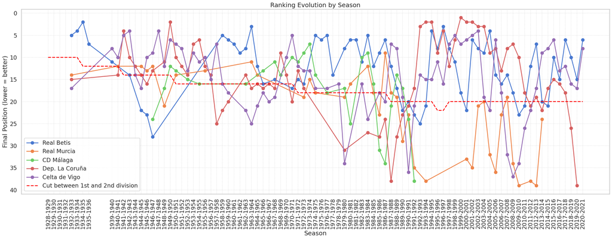

```python
teams=elevator_stats["team"].head(5)
plot_ranking_evolution(*teams).show()
```

## Exerise 10

Create a table that is the same as the one in exercise 7, but not only with the season final standings, but the standings at the end of each matchday. Columns are the same, including matchday that tells about which matchday from the season these standings are from. Would you be able to add a new column last_5 with the result of last 5 matches? This column should contain a list like ["W", "L", "W", "T", "T"]. In this list, the first item is the immediate previous match, the second one is the match before this one, and so on. If there are no 5 previous matches (because matchday < 6, for instance) then just make the list shorter.  
Save the final table in Excel with the name MatchdayStandings.xlsx in the reports/ folder

```python
def standings_by_matchday(df=df):

    home = df[['season','division','matchday','home_team','home_goals','away_goals']].copy()
    home = home.rename(columns={'home_team':'team','home_goals':'GF','away_goals':'GA'})
    home['result'] = home.apply(lambda x: 'W' if x['GF']>x['GA'] else ('L' if x['GF']<x['GA'] else 'T'), axis=1)

    away = df[['season','division','matchday','away_team','away_goals','home_goals']].copy()
    away = away.rename(columns={'away_team':'team','away_goals':'GF','home_goals':'GA'})
    away['result'] = away.apply(lambda x: 'W' if x['GF']>x['GA'] else ('L' if x['GF']<x['GA'] else 'T'), axis=1)

    matches = pd.concat([home, away], ignore_index=True)
    matches = matches.sort_values(['season','division','matchday']).reset_index(drop=True)

    def compute_last5(df):
        df = df.sort_values('matchday')
        results = []
        last5_list = []
        for res in df['result']:
            results.append(res)
            last5_list.append(results[-5:][::-1])
        df['last_5'] = last5_list
        return df

    matches = matches.groupby(['season','division','team']).apply(compute_last5).reset_index(drop=True)

    matches['W'] = (matches['result']=='W').astype(int)
    matches['L'] = (matches['result']=='L').astype(int)
    matches['T'] = (matches['result']=='T').astype(int)

    agg_cols = ['GF','GA','W','L','T']
    matches[agg_cols] = matches.groupby(['season','division','team'])[agg_cols].cumsum().astype(int)
    matches['GD'] = matches['GF'] - matches['GA']
    matches['Pts'] = matches['W']*3 + matches['T']

    standings_by_matchday = []
    for (season, division, matchday), group in matches.groupby(['season','division','matchday']):
        group = group.sort_values(by=['Pts','GD','GF'], ascending=[False,False,False])
        group['ranking'] = range(1, len(group)+1)
        standings_by_matchday.append(group)

    standings_by_matchday = pd.concat(standings_by_matchday)
    standings_by_matchday = standings_by_matchday[['season','division','matchday','ranking','team','GF','GA','GD','W','L','T','Pts','last_5']]
    standings_by_matchday = standings_by_matchday.sort_values(['season','division','matchday','ranking']).reset_index(drop=True)
    return standings_by_matchday
standings_day = standings_by_matchday()
standings_day
```

|  | season | division | matchday | ranking | team | GF | GA | GD | W | L | T | Pts | last_5 |
| --- | --- | --- | --- | --- | --- | --- | --- | --- | --- | --- | --- | --- | --- |
| 0 | 1928-1929 | 1 | 1 | 1 | Real Madrid | 5 | 0 | 5 | 1 | 0 | 0 | 3 | [W] |
| 1 | 1928-1929 | 1 | 1 | 2 | Barcelona | 2 | 0 | 2 | 1 | 0 | 0 | 3 | [W] |
| 2 | 1928-1929 | 1 | 1 | 3 | Athletic Madrid | 3 | 2 | 1 | 1 | 0 | 0 | 3 | [W] |
| 3 | 1928-1929 | 1 | 1 | 4 | Espanyol | 3 | 2 | 1 | 1 | 0 | 0 | 3 | [W] |
| 4 | 1928-1929 | 1 | 1 | 5 | Athletic | 1 | 1 | 0 | 0 | 0 | 1 | 1 | [T] |
| ... | ... | ... | ... | ... | ... | ... | ... | ... | ... | ... | ... | ... | ... |
| 95995 | 2021-2022 | 2 | 3 | 16 | Real Oviedo | 3 | 4 | -1 | 0 | 1 | 2 | 2 | [T, L, T] |
| 95996 | 2021-2022 | 2 | 3 | 17 | CD Lugo | 2 | 4 | -2 | 0 | 1 | 2 | 2 | [L, T, T] |
| 95997 | 2021-2022 | 2 | 3 | 18 | CD Leganés | 1 | 3 | -2 | 0 | 2 | 1 | 1 | [L, T, L] |
| 95998 | 2021-2022 | 2 | 3 | 19 | Burgos CF | 0 | 2 | -2 | 0 | 2 | 1 | 1 | [L, T, L] |
| 95999 | 2021-2022 | 2 | 3 | 20 | Alcorcón | 0 | 4 | -4 | 0 | 3 | 0 | 0 | [L, L, L] |

96000 rows × 13 columns

```python
# Save to Excel
os.makedirs('reports', exist_ok=True)
standings_day.to_excel('reports/MatchdayStandings.xlsx', index=False)
```

```python
# Import to HTML report
notebook_name = "notebooks/LaLigaDataAnalysis.ipynb"
output_dir = "reports"

os.makedirs(output_dir, exist_ok=True)

subprocess.run([
    "jupyter", "nbconvert",
    "--to", "html",
    "--output-dir", output_dir,
    notebook_name
])
```

[output not shown]

[output cut: 135 more lines]

[output not shown]

[output not shown]

[output not shown]